# Seasonal temperature changes in Arctic Alaska

# 1 Overview

This project seeks to answer the following research question:

**Is Arctic shrubification controlled by winter or summer temperatures?**

## 1.1 *Research Questions:*

This analysis is composed of four subquestions:

1. How has the mean **July** temperature of Arctic Alaska changed over the past 39 years (1979-2018)?
2. How has the mean **January** temperature of Arctic Alaska changed over the past 39 years?
3. Have **winter** or **summer** temperatures **changed more** over the study period?
4. Are there **any observable patterns of shrub expansion** that can be **explained by changes in winter or summer temperatures**?

## 1.2 *Rationale:*

- High latitude regions are projected to warm at twice the rate of the global average (IPCC 2013)
- Permafrost thaw releases greenhouse gases & contributes to more warming
- Shrubs are expanding & contribute to climate feedback cycles
  - Taller shrubs store more carbon - less carbon in atmosphere
  - Taller shrubs trap snow - soil is warmer during winter - increases permafrost thaw
- In order to model changes in vegetation and climate we need a thorough understanding of ecosystem processes
- However, the controls on shrub expansion are not well understood

## 1.3 *Data:*

**[NCEP-NCAR Reanalysis 1](http://www.esrl.noaa.gov/psd/data/gridded/data.ncep.reanalysis.derived.html)** (air.mon.mean)

**Source:** NCEP Reanalysis data provided by the NOAA/OAR/ESRL PSD, Boulder, Colorado, USA, from their Web site at https://www.esrl.noaa.gov/psd/

Note: this analysis was initally conducted using [NCEP North American Regional Reanalysis (NARR) monthly temperature at 2m height](https://www.esrl.noaa.gov/psd/data/gridded/data.narr.monolevel.html), however the current dataset was ultimately selected because the NARR data is projected on an irregular grid which presented difficulties for spatial analysis.

## 1.4 *Methodology:*

- Load and project shapefiles: World, Alaska, Alaskan Arctic
- Load NetCDF4 File
- Project temperature data
- Plot long term mean temperature by month
- Select region of interest and extract data
- Index plot of January temperatures
- Index plot of July temperatures

# 2 Load spatial data

## 2.1 Load packages

```r
# load packages
library(sf)
library(ncdf4)
library(raster)
library(rasterVis)
library(RColorBrewer)
library(maptools)
library(sp)
library(rgdal)
library(rgeos)
library(ggplot2)
```

## 2.2 Load and project shapefiles

```r
setwd('~/REarthSysSci')
# read the world shapefile
shp_path <- "~/REarthSysSci/gis/"
shp_name <- "ne_110m_admin_0_countries.shp"
shp_file <- paste(shp_path, shp_name, sep="")
world_shp <- read_sf(shp_file)
world_outline <- as(st_geometry(world_shp), Class="Spatial")

# read the Arctic shapefile
shp_name <- "alaska_arctic.shp"
shp_file <- paste(shp_path, shp_name, sep="")
arctic_shp <- read_sf(shp_file)
arctic_outline <- as(st_geometry(arctic_shp), Class="Spatial")

# read the Alaska shapefile
shp_name <- "alaska.shp"
shp_file <- paste(shp_path, shp_name, sep="")
alaska_shp <- read_sf(shp_file)
alaska_outline <- as(st_geometry(alaska_shp), Class="Spatial")

#project shapefiles

ak.proj <- "+proj=aea +lat_1=55 +lat_2=65 +lat_0=50 +lon_0=-154 +x_0=0 +y_0=0 +ellps=GRS80 +datum=NAD83 +units=m +no_defs"
arctic_proj <- spTransform(arctic_outline, CRS(ak.proj))
proj4string(world_outline) <- CRS("+proj=longlat")
world_proj <- spTransform(world_outline, CRS(ak.proj))
alaska_proj <- spTransform(alaska_outline, CRS(ak.proj))
```

# 3 Plot monthly average temperatures for Alaska

## 3.1 Load and project long-term mean temperature NetCDF file

```r
# create a lattice-style level plot showing monthly averages for alaska

#open the long term mean data
ncpath <- "/Users/Ori/Documents/REarthSysSci/"
ncname <- "air.mon.ltm.nc"
ncfname <- paste(ncpath, ncname, sep="")
dname <- "air"
temp_stack <-stack(ncfname)

r <- rotate(temp_stack)

ROI <- extent(-170,-150,50,75)

r.crop <- crop(r,ROI)

proj4string(r.crop) <- CRS("+proj=longlat")
lmt_proj<-projectRaster(r.crop, crs=ak.proj)

# replace layer names
names(lmt_proj) <- c("Jan","Feb","Mar","Apr","May","Jun","Jul","Aug","Sep","Oct","Nov","Dec")
```

## 3.2 Plot the average temperature by month

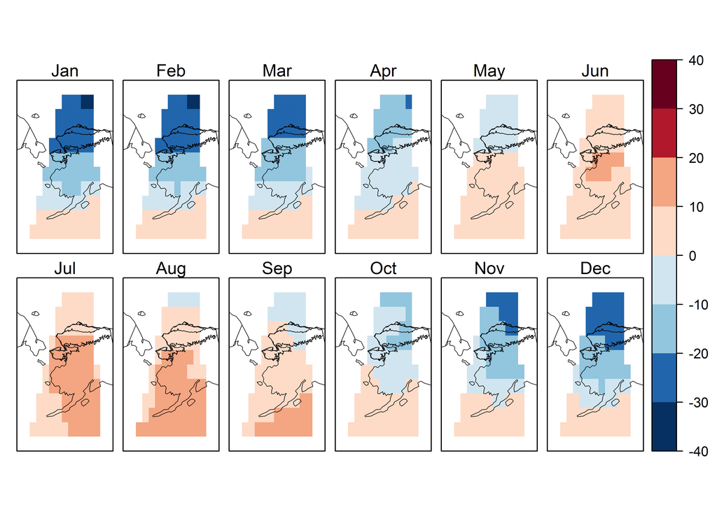

```r
# lattice-style levelplot

cutpts <- c(-40,-30,-20,-10,0,10,20,30,40)
plt <- levelplot(lmt_proj, at=cutpts, cuts=9, pretty=T,
          col.regions=(rev(brewer.pal(10,"RdBu"))),scales=list(draw=FALSE))
plt + latticeExtra::layer(sp.lines(world_proj, col="black", lwd=0.5))+ latticeExtra::layer(sp.lines(arctic_proj, col="black", lwd=0.5))
```

# 4 Plot January and July temperatures for Alaska

## 4.1 Load NetCDF file and project it

```r
# load netcdf file as a raster brick
ncpath <- "/Users/Ori/Documents/REarthSysSci/"
ncname <- "air.mon.mean"
ncfname <- paste(ncpath, ncname, ".nc", sep="")
dname <- "air"  # note: tmp means temperature (not temporary)

tmp_raster <- brick(ncfname, varname="air")
```

```r
#select region of interest and project temperature raster
r <- rotate(tmp_raster)

ROI <- extent(-180,-140,50,75)

r.crop <- crop(r,ROI)

proj4string(r.crop) <- CRS("+proj=longlat")
tmp_proj<-projectRaster(r.crop, crs=ak.proj)
```

## 4.2 Plot January 1979 temperatures

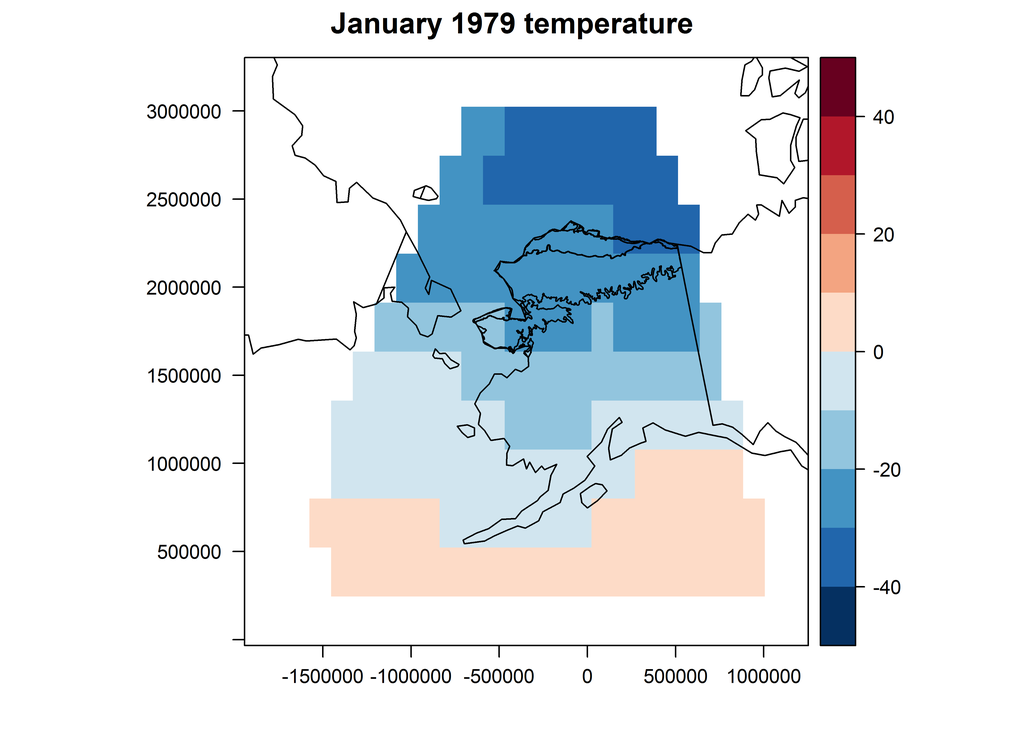

```r
# plot the first month (Jan 1979)
mapTheme <- rasterTheme(region = rev(brewer.pal(10, "RdBu")))
cutpts <- c(-50,-40,-30,-20,-10,0,10,20,30,40,50)
plt <- levelplot(subset(tmp_proj, 1), margin = F, at=cutpts, cuts=11, pretty=TRUE, par.settings = mapTheme,
  main="January 1979 temperature")
plt + latticeExtra::layer(sp.lines(world_proj, col="black", lwd=1.0))+ latticeExtra::layer(sp.lines(arctic_proj, col="black", lwd=1.0))
```

## 4.3 Plot July 1979 temperatures for comparison

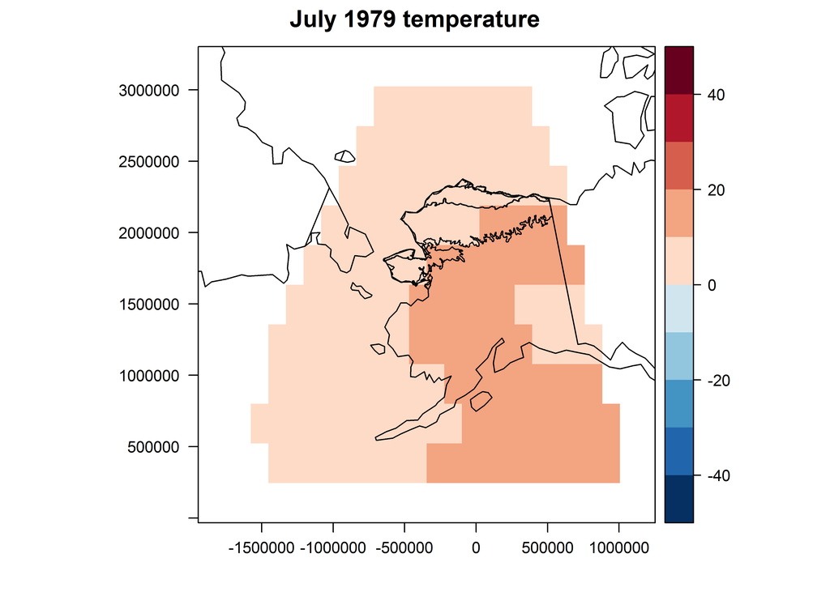

```r
# plot July 1979 for comparison
mapTheme <- rasterTheme(region = rev(brewer.pal(10, "RdBu")))
cutpts <- c(-50,-40,-30,-20,-10,0,10,20,30,40,50)
plt <- levelplot(subset(tmp_proj, 7), margin = F, at=cutpts, cuts=11, pretty=TRUE, par.settings = mapTheme,
  main="July 1979 temperature")
plt + latticeExtra::layer(sp.lines(world_proj, col="black", lwd=1.0))+ latticeExtra::layer(sp.lines(arctic_proj, col="black", lwd=1.0))
```

# 5 Extract temperature data from Arctic Alaska

## 5.1 Subset temperature data based upon spatial selection

```r
#subset the temperature data to focus on Arctic Alaska
arctic_buffer_75km <- st_buffer(arctic_shp, dist = 75000)

arctic_buffer_proj<-st_set_crs(arctic_buffer_75km, CRS(ak.proj))
arctic_buffer_proj<-as(st_geometry(arctic_buffer_proj), Class="Spatial")
arctic_buffer_proj <- spTransform(arctic_buffer_proj, CRS(ak.proj))

tmp_arctic<-mask(tmp_proj, arctic_buffer_proj)
```

## 5.2 Plot January 1979 temperature for the region

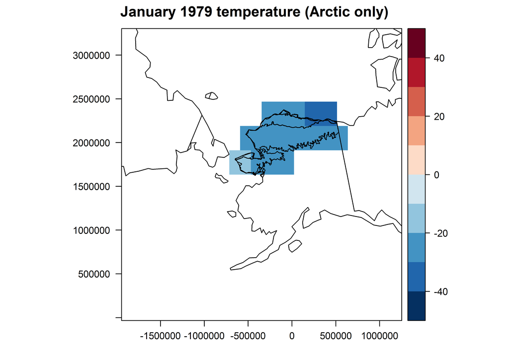

```r
#rasterVis plot
mapTheme <- rasterTheme(region = rev(brewer.pal(10, "RdBu")))
cutpts <- c(-50,-40,-30,-20,-10,0,10,20,30,40,50)
plt <- levelplot(subset(tmp_arctic,1), margin = F, at=cutpts, cuts=11, pretty=TRUE, par.settings = mapTheme,main="January 1979 temperature (Arctic only)")
plt + latticeExtra::layer(sp.lines(world_proj, col="black", lwd=1.0))+ latticeExtra::layer(sp.lines(arctic_proj, col="black", lwd=1.0))
```

## 5.3 Calculate monthly long-term mean temperatures for the Arctic

```r
ncpath <- "/Users/Ori/Documents/REarthSysSci/"
ncname <- "arctic_tmp"
ncfname <- paste(ncpath, ncname, ".nc", sep="")
dname <- "tmp"

# open a netCDF file
ncin <- nc_open(ncfname)

x <- ncvar_get(ncin,"lon")
xlname <- ncatt_get(ncin,"lon","long_name")
xunits <- ncatt_get(ncin,"lon","units")
nlon <- dim(x)

y <- ncvar_get(ncin,"lat")
ylname <- ncatt_get(ncin,"lat","long_name")
yunits <- ncatt_get(ncin,"lat","units")
nlat <- dim(y)

# get time
time <- ncvar_get(ncin,"time")
tunits <- ncatt_get(ncin,"time","units")
nt <- dim(time)

nm <- 12
ny <- nt/nm

# get years & generate months
year <- time/nm

month <- rep(seq(1:12), ny)


# get temperature
tmp_array <- ncvar_get(ncin,dname)
dlname <- ncatt_get(ncin,dname,"long_name")
dunits <- ncatt_get(ncin,dname,"units")
fillvalue <- ncatt_get(ncin,dname,"_FillValue")


# get global attributes
title <- ncatt_get(ncin,0,"title")
institution <- ncatt_get(ncin,0,"institution")
datasource <- ncatt_get(ncin,0,"source")
references <- ncatt_get(ncin,0,"references")
history <- ncatt_get(ncin,0,"history")
Conventions <- ncatt_get(ncin,0,"Conventions")

# close the netCDF file
nc_close(ncin)

# replace netCDF fill values with NA's
tmp_array[tmp_array==fillvalue$value] <- NA
```

```r
#write arctic-region temperature data to new ncdf file

tmpin<-tmp_arctic
outfile <- "arctic_tmp.nc"
crs(tmpin) <- ak.proj
writeRaster(tmpin, outfile, overwrite=TRUE, format="CDF", varname="tmp", varunit="degC",
  longname="Monthly Mean Air Temperature at sigma level 0.995", xname="lon", yname="lat",zname="time",zunit="months since 1978-12" )
```

```r
# get beginning obs of base period
begyr <- 1979; endyr <- 2018; nyrs <- endyr - begyr + 1
begobs <- 1
endobs <- 480
base_period <- paste(as.character(begyr)," - ", as.character(endyr), sep="")


# base-period array
tmp_array_base <- array(dim = c(nlon, nlat, nyrs * nm))

ny <- nyrs

tmp_array_base <- tmp_array[,, begobs:endobs]

# long-term means
tmp_ltm <- array(NA, dim = c(nlon, nlat, nm))


for (j in 1:nlon) {
  for (k in 1:nlat) {
    if (!is.na(tmp_array_base[j, k, 1])) {
      for (m in 1:nm)
        tmp_ltm[j, k, m] <- mean(tmp_array_base[j, k, seq(m, (m + nm*nyrs - 1), by=nm)])
    }
  }
}
```

## 5.4 Create a NetCDF of the Arctic mean temperature by month

```r
#write mean annual temperature by month for arctic region
# netCDF file of ltm's

# path and file name, set dname
ncpath <- "/Users/Ori/Documents/REarthSysSci/"
ncname <- "air.mon.mean_ltm_arctic.nc"
ncfname <- paste(ncpath, ncname, sep="")
dname <- "tmp_ltm"  # note: tmp means temperature (not temporary)

# get time values for output
time_out <- time[(begobs + (nyrs/2)*nm):(begobs + (nyrs/2)*nm + nm - 1)]
# recode NA's to fill_values
tmp_ltm[is.na(tmp_ltm)] <- fillvalue$value

# create and write the netCDF file -- ncdf4 version
# define dimensions
londim <- ncdim_def("lon","degrees_east",as.double(x))
latdim <- ncdim_def("lat","degrees_north",as.double(y))
timedim <- ncdim_def("time",tunits$value,as.double(time_out))

# define variables
dlname <- "Air Temperature at 2 m long-term mean"
tmp_def <- ncvar_def("tmp_ltm","degC",list(londim,latdim,timedim),fillvalue$value,dlname,prec="single")

# create netCDF file and put arrays
ncout <- nc_create(ncfname,tmp_def,force_v4=TRUE)

# put variables
ncvar_put(ncout,tmp_def,tmp_ltm)

# put additional attributes into dimension and data variables
ncatt_put(ncout,"lon","axis","X") #,verbose=FALSE) #,definemode=FALSE)
ncatt_put(ncout,"lat","axis","Y")
ncatt_put(ncout,"time","axis","T")
ncatt_put(ncout,"tmp_ltm","base_period", base_period)

# add global attributes
ncatt_put(ncout,0,"title",title$value)
ncatt_put(ncout,0,"institution",institution$value)
ncatt_put(ncout,0,"source",datasource$value)
ncatt_put(ncout,0,"references",references$value)
history <- paste("Ori Chafe", date(), sep=", ")
ncatt_put(ncout,0,"history",history)
ncatt_put(ncout,0,"Conventions",Conventions$value)



# close the file, writing data to disk
nc_close(ncout)
```

## 5.5 Calculate monthly temperature anomaly values in the Arctic

```r
# calculate anomalies
tmp_anm <- array(NA, dim = c(nlon, nlat, nt))
tmp_anm <- tmp_array_base - rep(tmp_ltm, ny)

# create netCDF file of anomalies

# path and file name, set dname
ncpath <- "/Users/Ori/Documents/REarthSysSci/"
ncname <- "air.mon.mean_anm_arctic_test3.nc"
ncfname <- paste(ncpath, ncname, sep="")
dname <- "tmp_anm"  # note: tmp means temperature (not temporary)

# recode NA's to fill_values
tmp_anm[is.na(tmp_anm)] <- fillvalue$value

# define dimensions
londim <- ncdim_def("lon","degrees_east",as.double(x))
latdim <- ncdim_def("lat","degrees_north",as.double(y))
timedim <- ncdim_def("time","months",as.double(time[1:480]))

# define variables
dlname <- "Air Temperature anomalies"
tmp_def <- ncvar_def("tmp_anm","degC",list(londim,latdim,timedim),fillvalue$value,dlname,prec="single")

# create netCDF file and put arrays
ncout <- nc_create(ncfname,tmp_def,force_v4=TRUE)

# put variables
ncvar_put(ncout,tmp_def,tmp_anm)

# put additional attributes into dimension and data variables
ncatt_put(ncout,"lon","axis","X") #,verbose=FALSE) #,definemode=FALSE)
ncatt_put(ncout,"lat","axis","Y")
ncatt_put(ncout,"time","axis","T")
ncatt_put(ncout,"tmp_anm","base_period", base_period)

# add global attributes
ncatt_put(ncout,0,"title",title$value)
ncatt_put(ncout,0,"institution",institution$value)
ncatt_put(ncout,0,"source",datasource$value)
ncatt_put(ncout,0,"references",references$value)
history <- paste("Ori Chafe", date(), sep=", ")
ncatt_put(ncout,0,"history",history)
ncatt_put(ncout,0,"Conventions",Conventions$value)

# close the file, writing data to disk
nc_close(ncout)
```

# 6 Plot temperature change over time

## 6.1 Load Arctic temperature anomaly dataset

```r
ncpath <- "/Users/Ori/Documents/REarthSysSci/"
ncname <- "air.mon.mean_anm_arctic_test3.nc"
ncfname <- paste(ncpath, ncname, sep="")
dname <- "tmp_anm"

tmp_raster <- brick(ncfname, varname="tmp_anm")
```

## 6.2 Plot the temperature anomalies over time

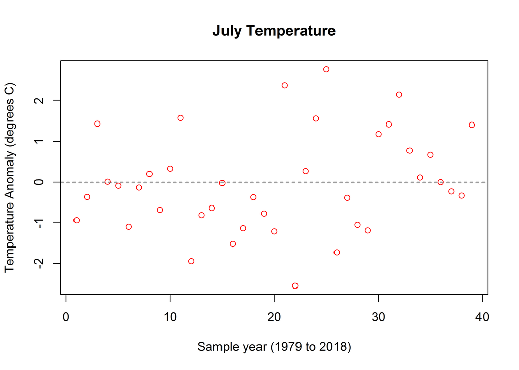

```
## integer(0)
```

```r
list_numbers <- seq(1:469)
list_filter <- sapply(list_numbers, function(x) {x %% 12 == 1})
jan <- list_numbers[list_filter]
list_filter <- sapply(list_numbers, function(x) {x %% 12 == 7})
jul <- list_numbers[list_filter]

plot(tmp_anm[14,4,jul], xlab="Sample year (1979 to 2018)", ylab="Temperature Anomaly (degrees C)", col="red",main="July Temperature")+ abline(h=0,lty=2)
```

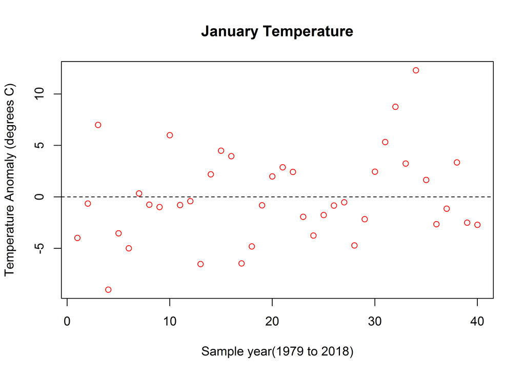

```
## integer(0)
```

```r
plot(tmp_anm[14,4,jan], xlab="Sample year(1979 to 2018)", ylab="Temperature Anomaly (degrees C)", col="red",main="January Temperature")+ abline(h=0,lty=2)
```

# 7 Plot temporal change in winter and summer temperatures

## 7.1 Create dataframe

```r
date<-jul
value<-tmp_anm[14,4,jul]
jul_anm<-tmp_anm[14,4,jul]
tmp_df_jul <- data.frame(date,value)
tmp_df_jul[1]<-tmp_df_jul[1]/12 +1979
tmp_df_jul["month"]<-"July"

value<-tmp_anm[14,4,jan]
date<-jan
jan_anm<-tmp_anm[14,4,jan]
jan_anm<-jan_anm[1:39]
tmp_df_jan <- data.frame(date,value)
tmp_df_jan[1]<-tmp_df_jan[1]/12 +1979
tmp_df_jan["month"]<-"January"

janjul_df <- rbind(tmp_df_jan, tmp_df_jul)
```

## 7.2 Plot seasonal temperature anomalies and long-term trends

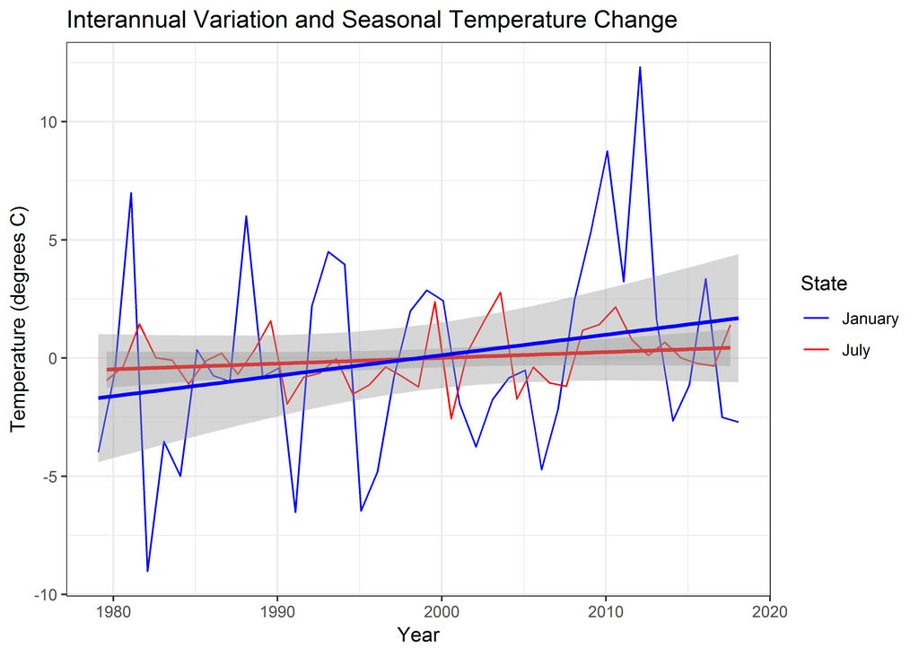

```r
ggplot(janjul_df, aes(x=date, y=value, color = variable)) + geom_line(aes(x=date,y = value, col = month)) + geom_smooth(method = "lm",data=tmp_df_jul, size=1, color="red") + geom_smooth(method = "lm",data=tmp_df_jan, size=1, color="blue")+ theme_bw()+xlab("Year")+ylab("Temperature (degrees C)")+ggtitle("Interannual Variation and Seasonal Temperature Change") + scale_color_manual(name="State",
                        labels = c("January","July"),
                        values = c("January"="blue","July"="red"))
```

# 8 Conclusion

- In the period from 1979 to 2018, both summer and winter temperatures in the Alaskan Arctic have increased.
- Winter temperatures have increased at a greater rate than summer temperatures, and could potentially be increasing shrub expansion.
- Additionally, in this region winter temperatures are more variable than summer temperatures.